# Engagement

```python
import pandas as pd
import numpy as np
import matplotlib.pyplot as plt
import seaborn as sns
import warnings
warnings.filterwarnings('ignore')
```

```python
df=pd.read_excel('/content/drive/MyDrive/AMA/Engagement_Case.xlsx')
df.head()
```

|  | age | income | previous_purchases | marketing_channel | gender | region | product_type | clicked_ad |
| --- | --- | --- | --- | --- | --- | --- | --- | --- |
| 0 | 56 | 59261 | 2 | 2 | 0 | 0 | 2 | 0 |
| 1 | 69 | 31997 | 3 | 2 | 0 | 0 | 0 | 0 |
| 2 | 46 | 34333 | 3 | 0 | 0 | 3 | 2 | 0 |
| 3 | 32 | 46664 | 4 | 3 | 1 | 2 | 0 | 0 |
| 4 | 60 | 54460 | 2 | 2 | 1 | 0 | 1 | 0 |

```python
df.isnull().sum()
```

|  | 0 |
| --- | --- |
| age | 0 |
| income | 0 |
| previous_purchases | 0 |
| marketing_channel | 0 |
| gender | 0 |
| region | 0 |
| product_type | 0 |
| clicked_ad | 0 |

**dtype:** int64

```python
from sklearn.model_selection import train_test_split
from sklearn.linear_model import LogisticRegression
from sklearn.preprocessing import StandardScaler, LabelEncoder
```

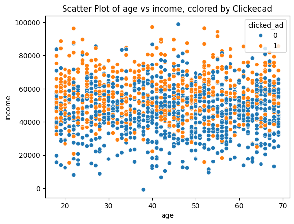

```python
sns.scatterplot(x='age', y='income', hue='clicked_ad', data=df)
plt.title('Scatter Plot of age vs income, colored by Clickedad')
plt.xlabel('age')
plt.ylabel('income')
plt.show()
```

```python
X = df.drop('clicked_ad', axis=1)
y = df['clicked_ad']
```

```python
X_train, X_test, y_train, y_test = train_test_split(X, y, test_size=0.3, random_state=24)
```

```python
scaler = StandardScaler()
X_train[['age', 'income','previous_purchases']] = scaler.fit_transform(X_train[['age', 'income','previous_purchases']])
X_test[['age', 'income','previous_purchases']] = scaler.transform(X_test[['age', 'income','previous_purchases']])
```

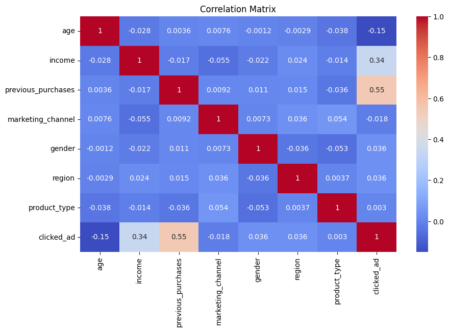

```python
plt.figure(figsize=(10, 6))
sns.heatmap(df.corr(), annot=True, cmap='coolwarm')
plt.title('Correlation Matrix')
plt.show()
```

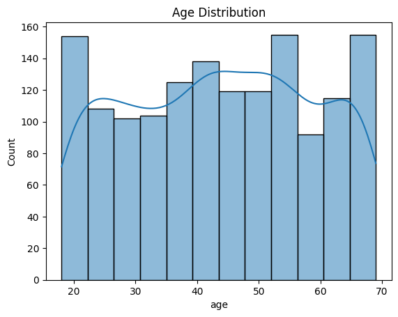

```python
sns.histplot(df['age'], kde=True)
plt.title('Age Distribution')
plt.show()
```

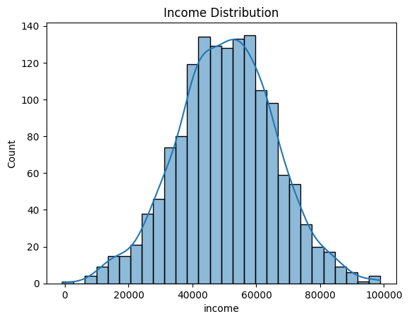

```python
sns.histplot(df['income'], kde=True)
plt.title('Income Distribution')
plt.show()
```

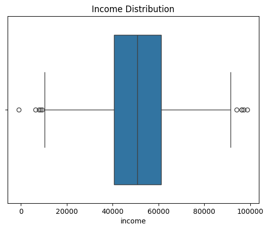

```python
sns.boxplot(x='income', data=df)
plt.title('Income Distribution')
plt.show()
```

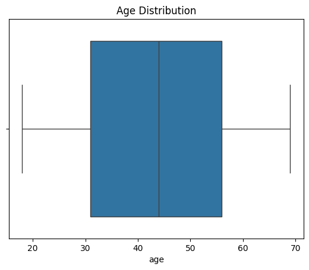

```python
sns.boxplot(x='age', data=df)
plt.title('Age Distribution')
plt.show()
```

```python
import statsmodels.api as sm
X_train_sm = sm.add_constant(X_train)

# Fit the logistic regression model
log_reg = sm.Logit(y_train, X_train_sm).fit()

# Print the summary of the model
print(log_reg.summary())
```

```
Optimization terminated successfully.
         Current function value: 0.379188
         Iterations 7
                           Logit Regression Results
==============================================================================
Dep. Variable:             clicked_ad   No. Observations:                 1040
Model:                          Logit   Df Residuals:                     1032
Method:                           MLE   Df Model:                            7
Date:                Wed, 22 Jan 2025   Pseudo R-squ.:                  0.4379
Time:                        03:40:47   Log-Likelihood:                -394.36
converged:                       True   LL-Null:                       -701.52
Covariance Type:            nonrobust   LLR p-value:                1.995e-128
======================================================================================
                         coef    std err          z      P>|z|      [0.025      0.975]
--------------------------------------------------------------------------------------
const                 -1.2077      0.246     -4.902      0.000      -1.691      -0.725
age                   -0.6151      0.095     -6.483      0.000      -0.801      -0.429
income                 1.2602      0.111     11.336      0.000       1.042       1.478
previous_purchases     2.0697      0.132     15.668      0.000       1.811       2.329
marketing_channel      0.0016      0.082      0.019      0.984      -0.158       0.161
gender                 0.1829      0.179      1.019      0.308      -0.169       0.535
region                 0.0828      0.082      1.008      0.314      -0.078       0.244
product_type           0.1745      0.111      1.570      0.116      -0.043       0.392
======================================================================================
```

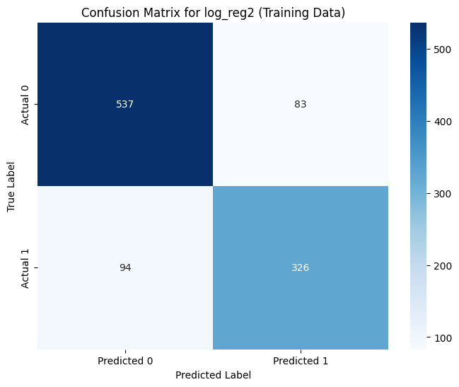

```python
from sklearn.metrics import confusion_matrix
y_pred_train = log_reg.predict(X_train_sm)

# Convert probabilities to class labels (0 or 1) using a threshold of 0.5
y_pred_train_class = (y_pred_train > 0.5).astype(int)

# Generate the confusion matrix
conf_matrix = confusion_matrix(y_train, y_pred_train_class)

# Plot the confusion matrix using seaborn
plt.figure(figsize=(8, 6))
sns.heatmap(conf_matrix, annot=True, fmt="d", cmap="Blues",
            xticklabels=['Predicted 0', 'Predicted 1'],
            yticklabels=['Actual 0', 'Actual 1'])
plt.title('Confusion Matrix for log_reg2 (Training Data)')
plt.xlabel('Predicted Label')
plt.ylabel('True Label')
plt.show()
```

```
Optimal Threshold: 0.45
Optimal Accuracy: 0.8346
```

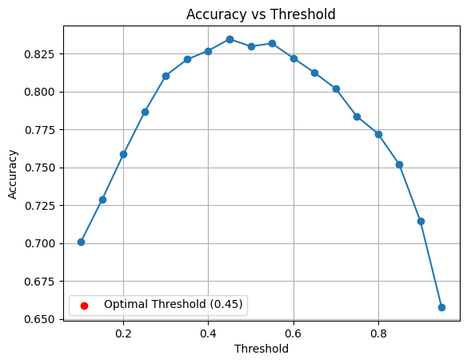

```python
from sklearn.metrics import accuracy_score

# Predict probabilities for the training data
y_pred_prob = log_reg.predict(X_train_sm)

# Test different thresholds
thresholds = np.arange(0.1, 1, 0.05)
accuracy_scores = []

for threshold in thresholds:
    y_pred_class = (y_pred_prob > threshold).astype(int)
    accuracy = accuracy_score(y_train, y_pred_class)
    accuracy_scores.append(accuracy)

# Find the optimal threshold that maximizes accuracy
optimal_threshold = thresholds[np.argmax(accuracy_scores)]
optimal_accuracy = np.max(accuracy_scores)

print(f"Optimal Threshold: {optimal_threshold:.2f}")
print(f"Optimal Accuracy: {optimal_accuracy:.4f}")


# Plot accuracy vs threshold
plt.plot(thresholds, accuracy_scores, marker='o')
plt.xlabel("Threshold")
plt.ylabel("Accuracy")
plt.title("Accuracy vs Threshold")
plt.scatter(optimal_threshold, optimal_accuracy, color='red', label=f'Optimal Threshold ({optimal_threshold:.2f})')
plt.legend()
plt.grid(True)
plt.show()
```

[figure not shown]

```python
y_pred_prob = log_reg.predict(X_train_sm)
y_pred_class = (y_pred_prob > 0.5).astype(int)

# Generate the confusion matrix
conf_matrix = confusion_matrix(y_train, y_pred_class)

# Plot the confusion matrix using seaborn
plt.figure(figsize=(8, 6))
sns.heatmap(conf_matrix, annot=True, fmt="d", cmap="Blues",
            xticklabels=['Predicted 0', 'Predicted 1'],
            yticklabels=['Actual 0', 'Actual 1'])
plt.title('Confusion Matrix for log_reg2 (Training Data) with Optimal Threshold = 0.35')
plt.xlabel('Predicted Label')
plt.ylabel('True Label')
plt.show()
```

```python
from sklearn.metrics import accuracy_score, recall_score, precision_score, f1_score

# Predict probabilities for the training data using the optimal threshold (0.32)
y_pred_prob = log_reg.predict(X_train_sm)
y_pred_class = (y_pred_prob > 0.30).astype(int)

# Calculate the model parameters
accuracy = accuracy_score(y_train, y_pred_class)
recall = recall_score(y_train, y_pred_class)
precision = precision_score(y_train, y_pred_class)
f1 = f1_score(y_train, y_pred_class)

print(f"Accuracy: {accuracy:.4f}")
print(f"Recall: {recall:.4f}")
print(f"Precision: {precision:.4f}")
print(f"F1 Score: {f1:.4f}")
```

```
Accuracy: 0.8106
Recall: 0.8976
Precision: 0.7100
F1 Score: 0.7928
```

```python
from sklearn.tree import DecisionTreeClassifier

# Initialize the CART model
cart_model = DecisionTreeClassifier(random_state=24)

# Fit the model to the training data (using the selected features)
cart_model.fit(X_train, y_train)
```

```
DecisionTreeClassifier(random_state=24)
```

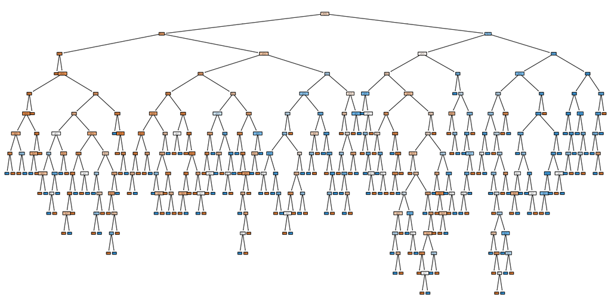

```python
from sklearn.tree import plot_tree

# Plot the decision tree
plt.figure(figsize=(20, 10))
plot_tree(cart_model, feature_names=X_train.columns, class_names=['0', '1'], filled=True, rounded=True)
plt.show()
```

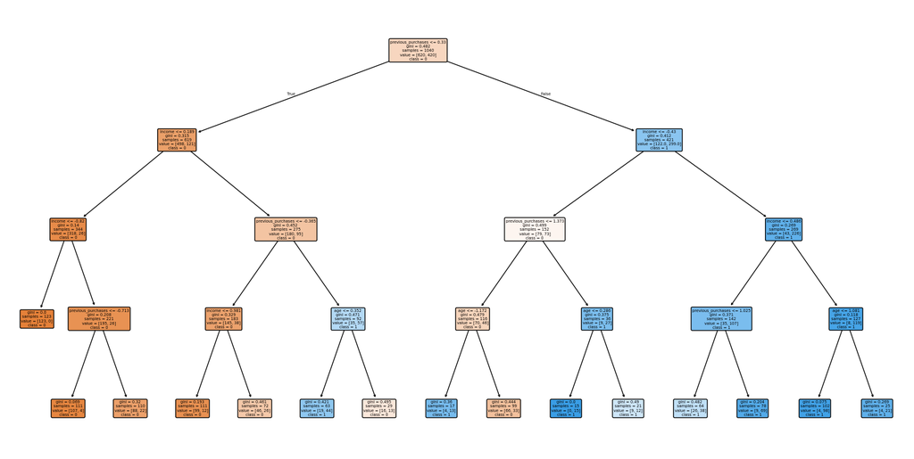

```python
# prompt: prune the tree for 4 levels

# Initialize the CART model with max_depth=4
cart_model = DecisionTreeClassifier(max_depth=4, random_state=24)

# Fit the model to the training data
cart_model.fit(X_train, y_train)

# Plot the decision tree
plt.figure(figsize=(20, 10))
plot_tree(cart_model, feature_names=X_train.columns, class_names=['0', '1'], filled=True, rounded=True)
plt.show()
```

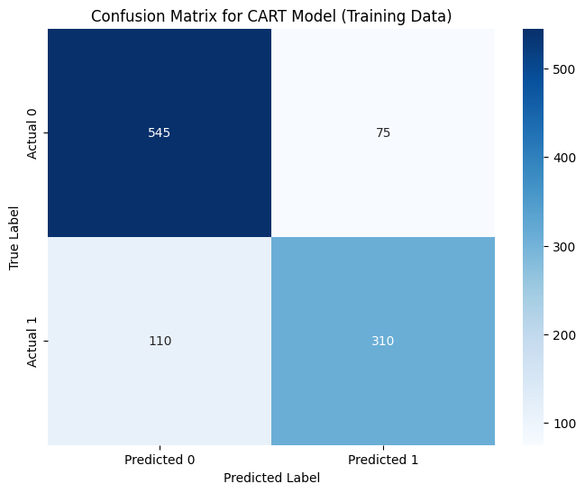

```
CART Model Performance (Training Data):
Accuracy: 0.8221
Precision: 0.8052
Recall: 0.7381
F1 Score: 0.7702
```

```python
# Predict on the training data
y_pred_cart = cart_model.predict(X_train)

# Create the confusion matrix
cm_cart = confusion_matrix(y_train, y_pred_cart)

# Plot the confusion matrix
plt.figure(figsize=(8, 6))
sns.heatmap(cm_cart, annot=True, fmt="d", cmap="Blues",
            xticklabels=['Predicted 0', 'Predicted 1'],
            yticklabels=['Actual 0', 'Actual 1'])
plt.title('Confusion Matrix for CART Model (Training Data)')
plt.xlabel('Predicted Label')
plt.ylabel('True Label')
plt.show()

# Calculate evaluation metrics
accuracy_cart = accuracy_score(y_train, y_pred_cart)
precision_cart = precision_score(y_train, y_pred_cart)
recall_cart = recall_score(y_train, y_pred_cart)
f1_cart = f1_score(y_train, y_pred_cart)

print(f"CART Model Performance (Training Data):")
print(f"Accuracy: {accuracy_cart:.4f}")
print(f"Precision: {precision_cart:.4f}")
print(f"Recall: {recall_cart:.4f}")
print(f"F1 Score: {f1_cart:.4f}")
```

**QUESTION 1**

**Customer Segmentation:**

**Customer Demographics with High Engagement**

Previous Purchases: Strong correlation (0.55) with clicked_ad. Prioritize targeting repeat buyers with personalized and loyalty-focused ads. Income: Moderate correlation (0.34). Target higher-income customers with premium and exclusive offerings. Age: Weak negative correlation (-0.15). Focus on younger audiences with trendy, visually appealing campaigns.

**Improving Segmentation Strategy**

Behavioral Targeting: Prioritize previous purchase history and income as key segmentation variables for personalization. Refined Segments: Combine weak variables (gender, region) with strong ones for nuanced targeting (e.g., premium buyers by region).

**QUESTION 2**

**Impact of Behavioral Factors:**

The correlation between previous_purchases and clicked_ad is 0.55, indicating a strong positive relationship. Customers with a history of making purchases are more likely to click on ads. This implies that these users are actively engaging with products and might respond positively to personalized advertisement

The correlation between product_type and clicked_ad is 0.003, suggesting a negligible relationship. This indicates that the type of product might not significantly influence whether a customer clicks on an ad. Other factors might play a more important role.

**Prioritization for Future Campaigns:**

1.Focus on Customers with Purchase History

2.Make use of the income and behavioral data.

**QUESTION 3**

**Model Selection**

Logistic Regression is preferred due to its interpretability, highlighting key factors like age and prior purchases for actionable insights. Its high recall (0.8976) ensures most engaging customers are identified, maximizing campaign reach. Additionally, it’s computationally simpler, scalable, and easier for non-technical stakeholders to understand and implement effectively.

**QUESTION 4**

**Marketing Channel Effectiveness:**

Correlation for marketing_channel (-0.018) suggests low overall effectiveness. Customization ensures better targeting.

**Conduct A/B Testing:**

Test campaigns on different channels (e.g., Google Ads vs. social media) to identify which ones resonate best with specific customer segments. Use key metrics such as conversion rates and cost-per-click for comparison.

Evaluate engagement metrics (e.g., CTR, ROI) for each channel across customer segments. Use behavioral factors like previous purchases and income to correlate ad performance with customer demographics

**QUESTION 5**

**Next Steps for Priya**

**Focus on Key Predictors:**

Previous Purchases (0.55) and Income (0.34): Target repeat and high-income customers with personalized campaigns. Age (-0.15): Focus on younger audiences via social media.

Deprioritize Weak Predictors: Ignore low-correlation variables like marketing channel (-0.018) and gender; use them as secondary filters.

Ensure Alignment: Set KPIs based on insights (e.g., CTR for high-income buyers). Use A/B testing to validate strategies. Share dashboards linking insights to campaign outcomes